Skip to main content

# How Likely Is ‘Likely’?

Author

Lukas

Published

November 10, 2026

## Introduction

This report analyzes the TidyTuesday dataset from Adam Kucharski’s online quiz “How likely is ‘likely’?”, in which more than 5,000 participants assigned numeric probabilities (0–100%) to 19 everyday probability phrases and compared pairs of those phrases. The quiz also collected respondent demographics such as age band, English-language background, education level, and country of residence. The released data include absolute probability judgements, pairwise comparison choices, and respondent metadata. Here I focus on two questions: (1) which phrases people disagree on most when translating them into numeric probabilities, and (2) which demographic backgrounds tend to assign higher probabilities—i.e., appear more “optimistic”—after controlling for phrase.

## Setup and Data Loading

The following chunk imports the packages used throughout the report.

```python
import pandas as pd
import numpy as np
import matplotlib.pyplot as plt
import seaborn as sns
from scipy import stats
```

Load the three raw CSVs from `../data/raw/` (paths are relative to the `analysis/` directory, where Quarto executes the notebook).

```python
judgements = pd.read_csv("../data/raw/absolute_judgements.csv")
pairwise = pd.read_csv("../data/raw/pairwise_comparisons.csv")
metadata = pd.read_csv("../data/raw/respondent_metadata.csv")

print("=== absolute_judgements ===")
judgements.info()
display(judgements.head())

print("=== pairwise_comparisons ===")
pairwise.info()
display(pairwise.head())

print("=== respondent_metadata ===")
metadata.info()
display(metadata.head())
```

```
=== absolute_judgements ===
<class 'pandas.DataFrame'>
RangeIndex: 98306 entries, 0 to 98305
Data columns (total 4 columns):
 #   Column       Non-Null Count  Dtype
---  ------       --------------  -----
 0   response_id  98306 non-null  int64
 1   term         98306 non-null  str
 2   probability  98306 non-null  int64
 3   order        98306 non-null  int64
dtypes: int64(3), str(1)
memory usage: 3.0 MB
```

|  | response_id | term | probability | order |
| --- | --- | --- | --- | --- |
| 0 | 5177 | Little Chance | 20 | 1 |
| 1 | 5177 | Almost No Chance | 9 | 2 |
| 2 | 5177 | Remote Chance | 18 | 3 |
| 3 | 5177 | May Happen | 44 | 4 |
| 4 | 5177 | Chances are Slight | 27 | 5 |

```
=== pairwise_comparisons ===
<class 'pandas.DataFrame'>
RangeIndex: 51740 entries, 0 to 51739
Data columns (total 5 columns):
 #   Column       Non-Null Count  Dtype
---  ------       --------------  -----
 0   response_id  51740 non-null  int64
 1   pair_id      51740 non-null  int64
 2   term1        51740 non-null  str
 3   term2        51740 non-null  str
 4   selected     51740 non-null  str
dtypes: int64(2), str(3)
memory usage: 2.0 MB
```

|  | response_id | pair_id | term1 | term2 | selected |
| --- | --- | --- | --- | --- | --- |
| 0 | 5177 | 1 | Very Good Chance | Remote Chance | Very Good Chance |
| 1 | 5177 | 2 | Almost No Chance | Realistic Possibility | Realistic Possibility |
| 2 | 5177 | 3 | Could Happen | Little Chance | Could Happen |
| 3 | 5177 | 4 | Chances are Slight | Improbable | Chances are Slight |
| 4 | 5177 | 5 | Probable | Unlikely | Probable |

```
=== respondent_metadata ===
<class 'pandas.DataFrame'>
RangeIndex: 5174 entries, 0 to 5173
Data columns (total 6 columns):
 #   Column                Non-Null Count  Dtype
---  ------                --------------  -----
 0   response_id           5174 non-null   int64
 1   timestamp             5174 non-null   str
 2   age_band              4737 non-null   str
 3   english_background    4753 non-null   str
 4   education_level       4511 non-null   str
 5   country_of_residence  4454 non-null   str
dtypes: int64(1), str(5)
memory usage: 242.7 KB
```

|  | response_id | timestamp | age_band | english_background | education_level | country_of_residence |
| --- | --- | --- | --- | --- | --- | --- |
| 0 | 5177 | 2026-02 | 45-54 | English is my first language | Bachelor | United States |
| 1 | 5176 | 2026-02 | 25-34 | English is my first language | Postgraduate | United States |
| 2 | 5175 | 2026-02 | NaN | NaN | NaN | NaN |
| 3 | 5174 | 2026-02 | 25-34 | English is my first language | Bachelor | Myanmar (Burma) |
| 4 | 5173 | 2026-02 | NaN | NaN | NaN | NaN |

## Data Checks

The TidyTuesday curators note that no cleaning was necessary. The checks below verify that claim for the absolute judgements and pairwise tables, and document missingness in the demographic metadata.

```python
# (a) Missing values per column
print("(a) Missing values per column")
print("absolute_judgements:\n", judgements.isna().sum().to_string(), "\n")
print("pairwise_comparisons:\n", pairwise.isna().sum().to_string(), "\n")
print("respondent_metadata:\n", metadata.isna().sum().to_string(), "\n")

# (b) Probability range
prob_min = judgements["probability"].min()
prob_max = judgements["probability"].max()
n_out_of_range = ((judgements["probability"] < 0) | (judgements["probability"] > 100)).sum()
print(f"(b) Probability min={prob_min}, max={prob_max}; outside 0-100: {n_out_of_range}")

# (c) Unique terms
terms = sorted(judgements["term"].unique())
print(f"(c) Unique terms: {len(terms)}")
print(terms)

# (d) Unique respondents and set differences
j_ids = set(judgements["response_id"].unique())
p_ids = set(pairwise["response_id"].unique())
m_ids = set(metadata["response_id"].unique())
print(
    f"(d) Unique respondents — judgements: {len(j_ids)}, "
    f"pairwise: {len(p_ids)}, metadata: {len(m_ids)}"
)
print(f"    In judgements but not metadata: {len(j_ids - m_ids)}")
print(f"    In metadata but not judgements: {len(m_ids - j_ids)}")
print(f"    In pairwise but not metadata: {len(p_ids - m_ids)}")

# (e) Terms per respondent
terms_per = judgements.groupby("response_id")["term"].nunique()
print("(e) Terms per respondent value counts:")
print(terms_per.value_counts().sort_index().to_string())
print(f"    Respondents with != 19 terms: {(terms_per != 19).sum()}")

# (f) Duplicate (response_id, term) rows
n_dup_pairs = judgements.duplicated(subset=["response_id", "term"]).sum()
print(f"(f) Duplicate (response_id, term) rows: {n_dup_pairs}")

# (g) Demographic unique values
print("(g) Demographic unique values")
print("age_band:", sorted(metadata["age_band"].dropna().unique().tolist()))
print(
    "english_background:",
    sorted(metadata["english_background"].dropna().unique().tolist()),
)
print(
    "education_level:",
    sorted(metadata["education_level"].dropna().unique().tolist()),
)
print(f"Unique countries: {metadata['country_of_residence'].nunique(dropna=True)}")
```

```
(a) Missing values per column
absolute_judgements:
 response_id    0
term           0
probability    0
order          0

pairwise_comparisons:
 response_id    0
pair_id        0
term1          0
term2          0
selected       0

respondent_metadata:
 response_id               0
timestamp                 0
age_band                437
english_background      421
education_level         663
country_of_residence    720

(b) Probability min=0, max=100; outside 0-100: 0
(c) Unique terms: 19
['About Even', 'Almost Certain', 'Almost No Chance', 'Better than Even', 'Chances are Slight', 'Could Happen', 'Highly Likely', 'Highly Unlikely', 'Improbable', 'Likely', 'Little Chance', 'May Happen', 'Might Happen', 'Probable', 'Realistic Possibility', 'Remote Chance', 'Unlikely', 'Very Good Chanc…
(d) Unique respondents — judgements: 5174, pairwise: 5174, metadata: 5174
    In judgements but not metadata: 0
    In metadata but not judgements: 0
    In pairwise but not metadata: 0
(e) Terms per respondent value counts:
term
19    5174
    Respondents with != 19 terms: 0
(f) Duplicate (response_id, term) rows: 0
(g) Demographic unique values
age_band: ['18-24', '25-34', '35-44', '45-54', '55-64', '65-74', '75+', 'Under 18']
english_background: ['English is my first language', 'English is not my first language and I am not fluent', 'English is not my first language but I am fluent']
education_level: ['Bachelor', 'High school', 'Less than high school', 'Postgraduate', 'Some college']
Unique countries: 64
```

**What the checks found.** Absolute judgements and pairwise comparisons have no missing values. All probability ratings fall within 0–100. There are exactly 19 unique terms, and every one of the 5,174 respondents appears in all three tables with no mismatches. Every respondent rated all 19 terms exactly once (no duplicate `(response_id, term)` rows). Demographic fields do have missing values: age band (437), English background (421), education level (663), and country of residence (720), with 64 unique countries among non-missing responses.

**Decisions.** No rows are dropped from the judgement or pairwise tables. For demographic analyses later, respondents with missing values on a given demographic variable are excluded from that variable’s grouping only (pairwise-complete cases). No imputation is applied.

## Question 1: Which phrases do people most disagree on, in relation to the probability they represent?

Using only `absolute_judgements`, I summarize how widely respondents disagree on the numeric probability attached to each phrase. **Disagreement** is defined as the standard deviation of assigned probabilities; the interquartile range (IQR) is used as a robustness check.

```python
grouped = judgements.groupby("term")["probability"]
term_summary = pd.DataFrame(
    {
        "n": grouped.count(),
        "mean": grouped.mean(),
        "median": grouped.median(),
        "std": grouped.std(),
        "iqr": grouped.quantile(0.75) - grouped.quantile(0.25),
        "p10": grouped.quantile(0.10),
        "p90": grouped.quantile(0.90),
    }
)
term_summary["p10_p90_range"] = term_summary["p90"] - term_summary["p10"]
term_summary = term_summary.sort_values("std", ascending=False).round(2)
term_summary.index.name = "term"
display(term_summary.reset_index())

rank_sd = term_summary["std"].rank(ascending=False)
rank_iqr = term_summary["iqr"].rank(ascending=False)
rank_compare = pd.DataFrame({"rank_by_std": rank_sd, "rank_by_iqr": rank_iqr})
print("Top 5 by SD:", term_summary.head(5).index.tolist())
print("Top 5 by IQR:", term_summary.sort_values("iqr", ascending=False).head(5).index.tolist())
display(rank_compare.sort_values("rank_by_std").head(10))

# Save Q1 summary for reuse
term_summary.reset_index().to_csv("../data/processed/term_summary.csv", index=False)
print("Wrote ../data/processed/term_summary.csv")
```

|  | term | n | mean | median | std | iqr | p10 | p90 | p10_p90_range |
| --- | --- | --- | --- | --- | --- | --- | --- | --- | --- |
| 0 | Realistic Possibility | 5174 | 56.97 | 60.0 | 20.55 | 35.0 | 25.0 | 80.0 | 55.0 |
| 1 | Could Happen | 5174 | 39.66 | 40.0 | 18.23 | 25.0 | 15.0 | 60.0 | 45.0 |
| 2 | Might Happen | 5174 | 39.96 | 40.0 | 17.66 | 25.0 | 15.0 | 60.0 | 45.0 |
| 3 | May Happen | 5174 | 41.88 | 40.0 | 17.02 | 21.0 | 20.0 | 60.0 | 40.0 |
| 4 | Highly Unlikely | 5174 | 9.21 | 5.0 | 12.41 | 5.0 | 1.0 | 20.0 | 19.0 |
| 5 | Probable | 5174 | 71.44 | 75.0 | 12.03 | 15.0 | 60.0 | 85.0 | 25.0 |
| 6 | Improbable | 5174 | 13.44 | 10.0 | 11.60 | 15.0 | 1.0 | 30.0 | 29.0 |
| 7 | Unlikely | 5174 | 19.01 | 20.0 | 11.30 | 15.0 | 5.0 | 30.0 | 25.0 |
| 8 | Highly Likely | 5174 | 85.33 | 90.0 | 10.89 | 10.0 | 75.0 | 95.0 | 20.0 |
| 9 | Likely | 5174 | 72.59 | 75.0 | 10.34 | 13.0 | 60.0 | 85.0 | 25.0 |
| 10 | Chances are Slight | 5174 | 13.00 | 10.0 | 10.21 | 10.0 | 5.0 | 25.0 | 20.0 |
| 11 | Very Good Chance | 5174 | 79.24 | 80.0 | 9.94 | 10.0 | 70.0 | 90.0 | 20.0 |
| 12 | Remote Chance | 5174 | 8.72 | 5.0 | 9.93 | 7.0 | 1.0 | 20.0 | 19.0 |
| 13 | Little Chance | 5174 | 11.68 | 10.0 | 8.08 | 10.0 | 5.0 | 20.0 | 15.0 |
| 14 | Will Happen | 5174 | 97.57 | 100.0 | 6.94 | 1.0 | 91.3 | 100.0 | 8.7 |
| 15 | Better than Even | 5174 | 58.12 | 60.0 | 6.85 | 5.0 | 51.0 | 65.0 | 14.0 |
| 16 | Almost No Chance | 5174 | 3.91 | 2.0 | 6.04 | 4.0 | 1.0 | 10.0 | 9.0 |
| 17 | Almost Certain | 5174 | 93.97 | 95.0 | 5.79 | 8.0 | 90.0 | 99.0 | 9.0 |
| 18 | About Even | 5174 | 49.96 | 50.0 | 3.66 | 0.0 | 50.0 | 50.0 | 0.0 |

```
Top 5 by SD: ['Realistic Possibility', 'Could Happen', 'Might Happen', 'May Happen', 'Highly Unlikely']
Top 5 by IQR: ['Realistic Possibility', 'Might Happen', 'Could Happen', 'May Happen', 'Unlikely']
```

| term | rank_by_std | rank_by_iqr |
| --- | --- | --- |
| Realistic Possibility | 1.0 | 1.0 |
| Could Happen | 2.0 | 2.5 |
| Might Happen | 3.0 | 2.5 |
| May Happen | 4.0 | 4.0 |
| Highly Unlikely | 5.0 | 15.5 |
| Probable | 6.0 | 6.0 |
| Improbable | 7.0 | 6.0 |
| Unlikely | 8.0 | 6.0 |
| Highly Likely | 9.0 | 10.5 |
| Likely | 10.0 | 8.0 |

```
Wrote ../data/processed/term_summary.csv
```

The table is sorted by standard deviation (descending). The top four phrases by SD — *Realistic Possibility*, *Could Happen*, *Might Happen*, and *May Happen* — are also the top four by IQR, so those rankings agree closely. Lower in the list, rankings diverge somewhat (for example *Highly Unlikely* ranks high on SD but much lower on IQR because of a long right tail), so IQR is a useful robustness check for outlier-driven disagreement.

The box plot below shows the full distribution of assigned probabilities for each phrase, ordered by median probability so that the typical ranking of phrases is easy to read.

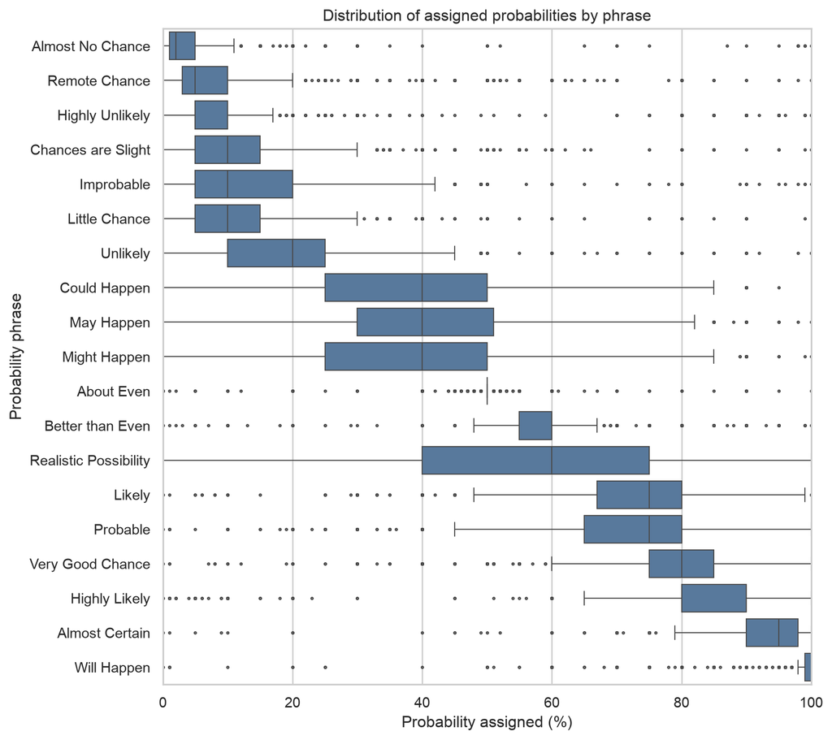

Horizontal box plots of assigned probability (%) by phrase, ordered by median probability.

```python
term_order_median = (
    judgements.groupby("term")["probability"].median().sort_values().index.tolist()
)
plot_df = judgements.copy()
plot_df["term"] = pd.Categorical(plot_df["term"], categories=term_order_median, ordered=True)

sns.set_theme(style="whitegrid", context="notebook")
fig, ax = plt.subplots(figsize=(9, 8))
sns.boxplot(
    data=plot_df,
    y="term",
    x="probability",
    color="#4C78A8",
    fliersize=1.5,
    linewidth=0.8,
    ax=ax,
)
ax.set_xlabel("Probability assigned (%)")
ax.set_ylabel("Probability phrase")
ax.set_title("Distribution of assigned probabilities by phrase")
ax.set_xlim(0, 100)
fig.tight_layout()
fig.savefig("../figures/q1_probability_by_term.png", dpi=200, bbox_inches="tight")
plt.show()
```

Extreme certainty phrases (*Almost No Chance*, *Almost Certain*, *Will Happen*, *About Even*) have tight boxes near the edges or at 50%, while mid-probability phrases such as *Could Happen*, *Might Happen*, *May Happen*, and *Realistic Possibility* show much wider spreads.

The bar chart below ranks phrases by disagreement (standard deviation), with the most disputed phrases at the top.

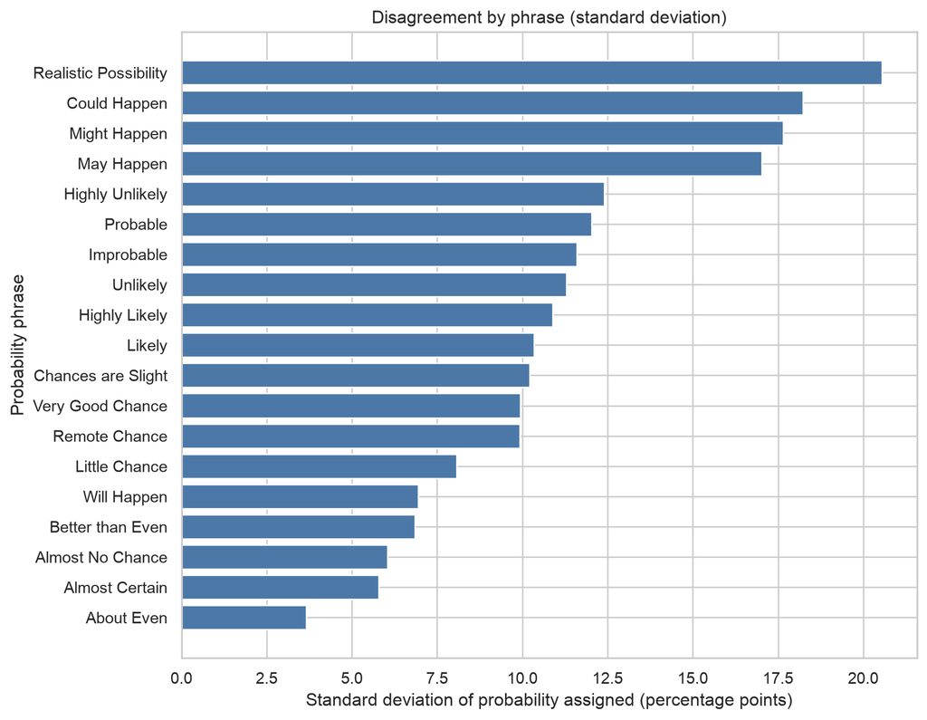

Standard deviation of assigned probability (%) by phrase, sorted descending so the most disputed phrases appear at the top.

```python
sd_order = term_summary["std"].sort_values(ascending=True)
fig, ax = plt.subplots(figsize=(9, 7))
ax.barh(sd_order.index, sd_order.values, color="#4C78A8")
ax.set_xlabel("Standard deviation of probability assigned (percentage points)")
ax.set_ylabel("Probability phrase")
ax.set_title("Disagreement by phrase (standard deviation)")
fig.tight_layout()
fig.savefig("../figures/q1_disagreement_by_term.png", dpi=200, bbox_inches="tight")
plt.show()
```

*Realistic Possibility* stands out with the largest standard deviation (~20.6 percentage points), followed by *Could Happen*, *Might Happen*, and *May Happen*. Phrases that imply near-certainty or near-impossibility, along with *About Even*, show the least disagreement.

**Answer to Question 1.** The most disputed phrases are *Realistic Possibility* (SD = 20.55, median = 60%), *Could Happen* (SD = 18.23, median = 40%), *Might Happen* (SD = 17.66, median = 40%), *May Happen* (SD = 17.02, median = 40%), and *Highly Unlikely* (SD = 12.41, median = 5%). Disagreement is highest for mid-range, hedged phrases whose typical ratings sit between roughly 40% and 60%, not for extreme phrases. Extreme phrases such as *About Even* (SD = 3.66), *Almost Certain* (SD = 5.79), and *Almost No Chance* (SD = 6.04) show much tighter agreement. The IQR ranking matches the SD ranking for the top mid-range phrases, which supports treating those phrases as the main locus of disagreement rather than an artifact of a few outliers.

## Question 2: Which demographic background is the most optimistic?

**Definition of “optimistic”.** Here, a more optimistic respondent is one who assigns *higher probabilities to the same phrases on average*. That is a narrow, operational definition: it captures a tendency toward higher numeric ratings, not broader psychological optimism, risk appetite, or beliefs about future events. Limits of this definition include that (1) all phrases are rated in isolation from real-world stakes, (2) higher ratings on low-probability phrases and high-probability phrases are treated the same after centering, and (3) demographic differences may reflect language interpretation rather than outlook.

To control for term, I subtract each term’s overall mean probability from each judgement, then average those deviations within respondent. I also compute each respondent’s raw mean probability for comparison.

```python
# Term-level means and per-judgement deviations
term_mean_map = judgements.groupby("term")["probability"].mean()
judgements = judgements.copy()
judgements["term_mean"] = judgements["term"].map(term_mean_map)
judgements["deviation"] = judgements["probability"] - judgements["term_mean"]

# Respondent-level optimism scores
respondent_optimism = (
    judgements.groupby("response_id")
    .agg(
        mean_deviation=("deviation", "mean"),
        raw_mean_probability=("probability", "mean"),
        n_terms=("term", "count"),
    )
    .reset_index()
)

# Merge demographics
respondent_optimism = respondent_optimism.merge(metadata, on="response_id", how="left")

print(respondent_optimism[["mean_deviation", "raw_mean_probability"]].describe().round(3))
print(
    "Correlation between raw mean and mean deviation:",
    round(
        respondent_optimism["mean_deviation"].corr(
            respondent_optimism["raw_mean_probability"]
        ),
        4,
    ),
)
display(respondent_optimism.head())

# Save respondent-level optimism scores with metadata
respondent_optimism.to_csv("../data/processed/respondent_optimism.csv", index=False)
print("Wrote ../data/processed/respondent_optimism.csv")
```

```
       mean_deviation  raw_mean_probability
count        5174.000              5174.000
mean           -0.000                45.560
std             4.890                 4.890
min           -45.560                 0.000
25%            -3.139                42.421
50%             0.176                45.737
75%             3.124                48.684
max            36.966                82.526
Correlation between raw mean and mean deviation: 1.0
```

|  | response_id | mean_deviation | raw_mean_probability | n_terms | timestamp | age_band | english_background | education_level | country_of_residence |
| --- | --- | --- | --- | --- | --- | --- | --- | --- | --- |
| 0 | 4 | -0.560495 | 45.000000 | 19 | 2026-01 | 35-44 | English is my first language | NaN | NaN |
| 1 | 5 | 2.071084 | 47.631579 | 19 | 2026-01 | 35-44 | English is my first language | NaN | NaN |
| 2 | 6 | -6.823653 | 38.736842 | 19 | 2026-01 | 25-34 | English is not my first language but I am fluent | NaN | NaN |
| 3 | 7 | 3.965821 | 49.526316 | 19 | 2026-01 | 45-54 | English is my first language | NaN | NaN |
| 4 | 8 | -2.034179 | 43.526316 | 19 | 2026-01 | 35-44 | English is my first language | NaN | NaN |

```
Wrote ../data/processed/respondent_optimism.csv
```

Because every respondent rated the same 19 terms, mean deviation equals the raw mean probability minus a constant (the average of the 19 term means). The two scores are therefore perfectly correlated here; the deviation form still makes the “relative to the phrase mean” interpretation explicit for later group comparisons.

Group comparisons use a minimum of **30 respondents** per group. Groups below that threshold are excluded from ranking. Confidence intervals are **t-based 95% CIs** for the mean deviation. Kruskal–Wallis tests summarize overall differences; effect sizes (approximate η²) are emphasized over p-values. For country, only the top 15 countries by respondent count among those meeting the n ≥ 30 rule are shown (here, 12 countries qualify).

```python
MIN_N = 30


def group_comparison(df, col, label, top_n=None):
    """Mean deviation by group with t-based 95% CI; keep groups with n >= MIN_N."""
    sub = df.dropna(subset=[col, "mean_deviation"]).copy()
    rows = []
    for name, s in sub.groupby(col)["mean_deviation"]:
        n = int(s.shape[0])
        mean = float(s.mean())
        if n > 1:
            se = float(s.std(ddof=1) / np.sqrt(n))
            tcrit = float(stats.t.ppf(0.975, df=n - 1))
            ci_low, ci_high = mean - tcrit * se, mean + tcrit * se
        else:
            ci_low = ci_high = np.nan
        rows.append(
            {
                "group": name,
                "n": n,
                "mean_deviation": mean,
                "ci_low": ci_low,
                "ci_high": ci_high,
            }
        )
    out = pd.DataFrame(rows)
    n_total_groups = out.shape[0]
    out_qual = out[out["n"] >= MIN_N].copy()
    n_excluded = n_total_groups - out_qual.shape[0]

    if top_n is not None:
        counts = sub.groupby(col).size().sort_values(ascending=False)
        qualifying_counts = counts[counts >= MIN_N]
        top_groups = qualifying_counts.head(top_n).index
        out_qual = out_qual[out_qual["group"].isin(top_groups)]

    out_qual = out_qual.sort_values("mean_deviation", ascending=False).reset_index(
        drop=True
    )
    out_qual[["mean_deviation", "ci_low", "ci_high"]] = out_qual[
        ["mean_deviation", "ci_low", "ci_high"]
    ].round(3)

    # Kruskal-Wallis on all n >= MIN_N groups for this variable
    keep = sub.groupby(col).filter(lambda g: len(g) >= MIN_N)
    samples = [g["mean_deviation"].values for _, g in keep.groupby(col)]
    if len(samples) >= 2:
        H, p = stats.kruskal(*samples)
        k = len(samples)
        n = sum(len(s) for s in samples)
        eta2 = (H - k + 1) / (n - k) if (n - k) > 0 else np.nan
    else:
        H = p = eta2 = np.nan
        k = n = 0

    print(f"=== {label} ({col}) ===")
    print(
        f"Groups with n >= {MIN_N}: {out_qual.shape[0]} shown; "
        f"excluded below threshold: {n_excluded}"
        + (f"; capped at top {top_n} by count" if top_n else "")
    )
    display(out_qual)
    print(
        f"Kruskal-Wallis H={H:.2f}, p={p:.3g}, approx eta^2={eta2:.4f} "
        f"(k={k} groups, n={n} respondents)"
    )
    spread = out_qual["mean_deviation"].max() - out_qual["mean_deviation"].min()
    print(f"Spread (max − min mean deviation): {spread:.3f} percentage points\n")
    return out_qual


age_tbl = group_comparison(respondent_optimism, "age_band", "Age band")
eng_tbl = group_comparison(
    respondent_optimism, "english_background", "English background"
)
edu_tbl = group_comparison(respondent_optimism, "education_level", "Education level")
country_tbl = group_comparison(
    respondent_optimism,
    "country_of_residence",
    "Country of residence",
    top_n=15,
)

# Store for plotting
q2_tables = {
    "Age band": age_tbl,
    "English background": eng_tbl,
    "Education level": edu_tbl,
    "Country of residence": country_tbl,
}
```

```
=== Age band (age_band) ===
Groups with n >= 30: 7 shown; excluded below threshold: 1
```

|  | group | n | mean_deviation | ci_low | ci_high |
| --- | --- | --- | --- | --- | --- |
| 0 | 18-24 | 141 | 0.612 | -0.108 | 1.332 |
| 1 | 35-44 | 1405 | 0.369 | 0.116 | 0.622 |
| 2 | 25-34 | 868 | 0.323 | 0.005 | 0.640 |
| 3 | 75+ | 79 | 0.189 | -0.904 | 1.282 |
| 4 | 45-54 | 1163 | -0.301 | -0.568 | -0.033 |
| 5 | 65-74 | 328 | -0.367 | -0.963 | 0.229 |
| 6 | 55-64 | 734 | -0.869 | -1.238 | -0.499 |

```
Kruskal-Wallis H=37.45, p=1.44e-06, approx eta^2=0.0067 (k=7 groups, n=4718 respondents)
Spread (max − min mean deviation): 1.481 percentage points

=== English background (english_background) ===
Groups with n >= 30: 3 shown; excluded below threshold: 0
```

|  | group | n | mean_deviation | ci_low | ci_high |
| --- | --- | --- | --- | --- | --- |
| 0 | English is not my first language and I am not ... | 40 | 0.374 | -2.419 | 3.166 |
| 1 | English is my first language | 3993 | -0.012 | -0.161 | 0.137 |
| 2 | English is not my first language but I am fluent | 720 | -0.056 | -0.424 | 0.312 |

```
Kruskal-Wallis H=0.06, p=0.968, approx eta^2=-0.0004 (k=3 groups, n=4753 respondents)
Spread (max − min mean deviation): 0.430 percentage points

=== Education level (education_level) ===
Groups with n >= 30: 4 shown; excluded below threshold: 1
```

|  | group | n | mean_deviation | ci_low | ci_high |
| --- | --- | --- | --- | --- | --- |
| 0 | High school | 103 | 2.327 | 1.297 | 3.357 |
| 1 | Some college | 263 | 1.382 | 0.784 | 1.979 |
| 2 | Bachelor | 1437 | 0.271 | 0.020 | 0.521 |
| 3 | Postgraduate | 2699 | -0.351 | -0.531 | -0.171 |

```
Kruskal-Wallis H=59.56, p=7.3e-13, approx eta^2=0.0126 (k=4 groups, n=4502 respondents)
Spread (max − min mean deviation): 2.678 percentage points

=== Country of residence (country_of_residence) ===
Groups with n >= 30: 12 shown; excluded below threshold: 52; capped at top 15 by count
```

|  | group | n | mean_deviation | ci_low | ci_high |
| --- | --- | --- | --- | --- | --- |
| 0 | United States | 1436 | 0.656 | 0.398 | 0.914 |
| 1 | Ireland | 50 | 0.596 | -0.889 | 2.082 |
| 2 | Netherlands | 48 | 0.347 | -0.840 | 1.535 |
| 3 | France | 42 | 0.319 | -1.236 | 1.875 |
| 4 | Italy | 39 | 0.280 | -2.200 | 2.761 |
| 5 | Germany | 108 | 0.171 | -0.757 | 1.099 |
| 6 | Canada | 161 | 0.126 | -0.673 | 0.924 |
| 7 | Switzerland | 46 | 0.083 | -1.407 | 1.572 |
| 8 | Australia | 121 | -0.319 | -1.343 | 0.705 |
| 9 | United Kingdom | 2018 | -0.430 | -0.627 | -0.232 |
| 10 | New Zealand | 52 | -0.643 | -1.951 | 0.664 |
| 11 | Norway | 74 | -2.026 | -3.043 | -1.008 |

```
Kruskal-Wallis H=64.08, p=1.61e-09, approx eta^2=0.0127 (k=12 groups, n=4195 respondents)
Spread (max − min mean deviation): 2.682 percentage points
```

The forest-style plots below show each group’s mean deviation with its 95% t-based CI. Groups are ordered by mean deviation; the dashed line at 0 is the overall phrase-adjusted average.

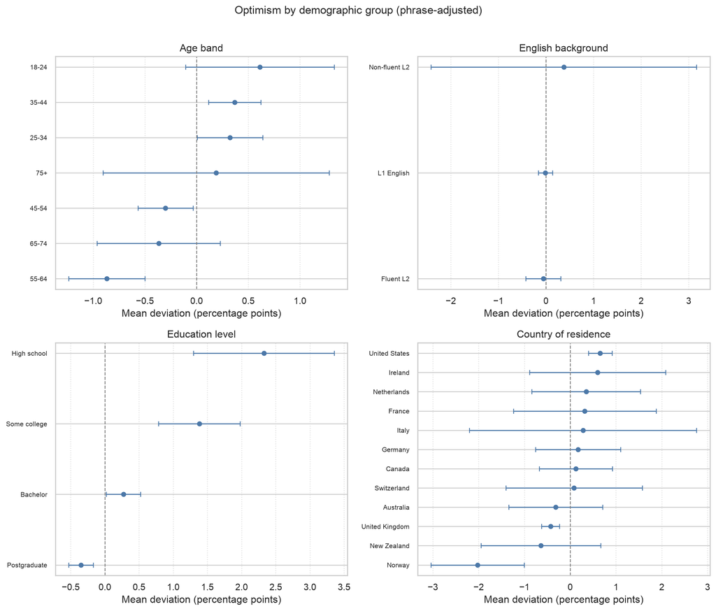

Mean phrase-adjusted probability deviation (percentage points) by demographic group, with 95% t-based confidence intervals. Positive values indicate higher-than-average probability assignments (more ‘optimistic’ under the operational definition).

```python
fig, axes = plt.subplots(2, 2, figsize=(12, 10))
panel_order = [
    ("Age band", age_tbl),
    ("English background", eng_tbl),
    ("Education level", edu_tbl),
    ("Country of residence", country_tbl),
]

for ax, (title, tbl) in zip(axes.flat, panel_order):
    # Order ascending so highest optimism appears at top of horizontal plot
    plot_tbl = tbl.sort_values("mean_deviation", ascending=True).reset_index(drop=True)
    y = np.arange(len(plot_tbl))
    x = plot_tbl["mean_deviation"].values
    xerr = np.vstack(
        [
            x - plot_tbl["ci_low"].values,
            plot_tbl["ci_high"].values - x,
        ]
    )
    ax.errorbar(
        x,
        y,
        xerr=xerr,
        fmt="o",
        color="#4C78A8",
        ecolor="#4C78A8",
        elinewidth=1.2,
        capsize=3,
        markersize=5,
    )
    ax.axvline(0, color="gray", linestyle="--", linewidth=1)
    ax.set_yticks(y)
    # Shorten long English labels for readability
    labels = [
        (
            g.replace("English is not my first language and I am not fluent", "Non-fluent L2")
            .replace("English is not my first language but I am fluent", "Fluent L2")
            .replace("English is my first language", "L1 English")
        )
        for g in plot_tbl["group"]
    ]
    ax.set_yticklabels(labels, fontsize=8)
    ax.set_xlabel("Mean deviation (percentage points)")
    ax.set_title(title)
    ax.grid(axis="x", linestyle=":", alpha=0.6)

fig.suptitle("Optimism by demographic group (phrase-adjusted)", fontsize=13, y=1.01)
fig.tight_layout()
fig.savefig("../figures/q2_optimism_by_demographic.png", dpi=200, bbox_inches="tight")
plt.show()
```

Across panels, education and country show clearer separations than English background. High school and some-college groups sit above zero, while postgraduate sits slightly below; among countries with enough respondents, the United States is above zero and Norway is below.

**Answer to Question 2.** By age band, the highest mean deviation is *18–24* (+0.61 pp) and the lowest is *55–64* (−0.87 pp), a spread of about 1.5 percentage points. By English background, differences are tiny (spread ≈ 0.43 pp), with overlapping confidence intervals. By education, *High school* is highest (+2.33 pp) and *Postgraduate* is lowest (−0.35 pp), a spread of about 2.68 pp. Among countries with n ≥ 30, the United States is highest (+0.66 pp) and Norway is lowest (−2.03 pp), a spread of about 2.68 pp. Education level and country of residence show the largest spreads; English background shows almost none. Even the largest demographic spreads (~2.7 pp) are much smaller than term-level disagreement in Question 1, where the most disputed phrase had a standard deviation of about 20.6 percentage points.

## Limitations and Takeaways

- **Q1 takeaway:** People disagree most on mid-range, hedged phrases (*Realistic Possibility*, *Could Happen*, *Might Happen*, *May Happen*), with standard deviations around 17–21 percentage points, while extreme certainty phrases are comparatively consistent.
- **Q2 takeaway:** Under an operational definition of optimism as higher phrase-adjusted probability ratings, education and country show the largest group spreads (~2.7 pp), while English-background differences are negligible; all demographic spreads are far smaller than phrase-level disagreement.
- **Observational data:** Associations between demographics and ratings are descriptive only; this analysis does not support causal claims.
- **Self-selected online quiz:** Participants opted into Adam Kucharski’s quiz, so the sample is not a probability sample of any defined population.
- **Non-representative demographics:** Respondents skew toward certain countries (especially the UK and US), higher education levels, and adult age bands; missing demographic fields further limit generalizability.
- **No causal claims:** Differences by age, education, or country should not be interpreted as effects of those characteristics on probability language use.